# RF_BalancedTrain_DP

Sofia Pozsonyiova

2/15/2023

```r
set.seed(707)
# Libraries
library(ggplot2)
library(gridExtra)
library(dplyr)
library(caret)
library(rpart)
library(rpart.plot)
library(class)
library(randomForest)
library(infer)
```

# Data

```r
# Loading in data from github
# Training
load("/Users/sofiapozsonyiova/Documents/GitHub/Private707/data/Balanced/ModelDev_Train_BalancedUSE.RData")

# Testing
load("/Users/sofiapozsonyiova/Documents/GitHub/Private707/data/Balanced/FinalValidation_UnbalancedUSE.RData")
```

# All Variables: CV

## Data

```r
# Selecting clusters that are needed
Train_All <- Train_Model_Dev_Balanced %>% select(-P28)
```

Cross Validation v. OOB

In k-fold cross-validation, the data is divided into k equally sized folds, and the model is trained and tested k times. In each iteration, the model is trained on k-1 folds and tested on the remaining fold, with a different fold used for testing in each iteration. This allows for all data to be used for training and testing, and the average performance across all folds is used as the final model evaluation.

In the OOB method, the data is split into a training set and a testing set. The model is trained on the training set, and predictions are made on the testing set. However, in random forest models, each tree is trained on a bootstrap sample of the training set, which means that some samples are not included in the bootstrap sample for a given tree. These samples are referred to as out-of-bag samples. The model can then be evaluated on these out-of-bag samples, providing an estimate of performance without the need for a separate test set.

In general, cross-validation is preferred over the OOB method because it allows for a more robust estimate of model performance. Cross-validation uses all the data for both training and testing, and the evaluation is based on the average performance across all folds, which can help reduce the variance in the estimated performance. However, the OOB method can still be useful, especially when data is limited, as it provides an estimate of performance without requiring a separate test set.

### Training: All Variables Included

```r
# Initializing Random Forest
forest_modelAll <- train(
  SelfPerceivedHealth ~ .,
  data = Train_All,
  method = "rf",
  tuneGrid = data.frame(mtry = c(2,12,63,126)),
  trControl = trainControl(method = "cv",number = 10),
  metric = "Accuracy",
  na.action = na.omit)
```

```r
# Printing results
print(forest_modelAll)
```

```
## Random Forest
##
## 8718 samples
##  126 predictor
##    2 classes: '0', '1'
##
## No pre-processing
## Resampling: Cross-Validated (10 fold)
## Summary of sample sizes: 7846, 7846, 7847, 7846, 7847, 7846, ...
## Resampling results across tuning parameters:
##
##   mtry  Accuracy   Kappa
##     2   0.8758874  0.7517759
##    12   0.8972230  0.7944460
##    63   0.8973376  0.7946756
##   126   0.8940117  0.7880236
##
## Accuracy was used to select the optimal model using the largest value.
## The final value used for the model was mtry = 63.
```

```r
forest_modelAll$results
```

```
##   mtry  Accuracy     Kappa  AccuracySD    KappaSD
## 1    2 0.8758874 0.7517759 0.009229558 0.01845819
## 2   12 0.8972230 0.7944460 0.008498994 0.01699759
## 3   63 0.8973376 0.7946756 0.010897884 0.02179294
## 4  126 0.8940117 0.7880236 0.009092066 0.01818152
```

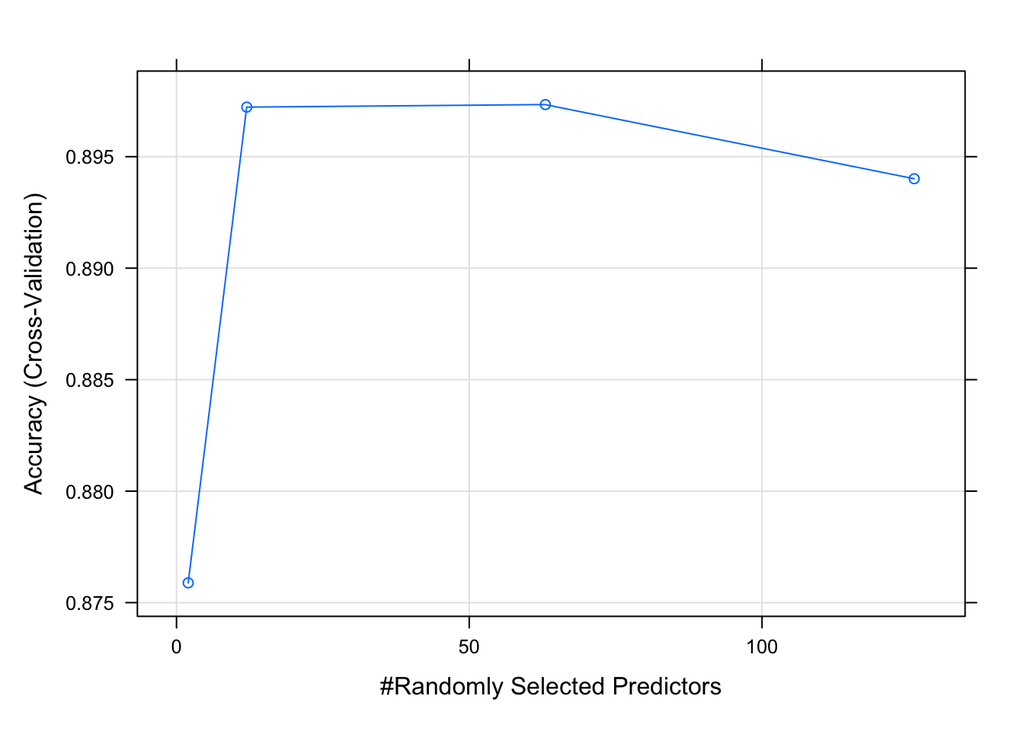

```r
#Visualizing results
plot(forest_modelAll)
```

```r
# Final model Forest
forest_modelAll$finalModel
```

```
##
## Call:
##  randomForest(x = x, y = y, mtry = min(param$mtry, ncol(x)))
##                Type of random forest: classification
##                      Number of trees: 500
## No. of variables tried at each split: 63
##
##         OOB estimate of  error rate: 10.05%
## Confusion matrix:
##      0    1 class.error
## 0 3797  562  0.12892865
## 1  314 4045  0.07203487
```

```r
## Get variable importance, and turn into a data frame
var_impAll <- varImp(forest_modelAll, scale=FALSE)$importance
var_impAll <- data.frame(variables=row.names(var_impAll), importance=var_impAll$Overall)
var_impAll %>% arrange(desc(importance))
```

```
##              variables   importance
## 1                 P49f 518.33463074
## 2                 P49a 351.61975234
## 3                 P50b 278.83343127
## 4                 P49l 214.28409870
## 5                 P26a 128.37391598
## 6                 P342 125.98437304
## 7                 P49h 111.40593648
## 8                  P37 102.64365139
## 9                 P47e  94.93650950
## 10                 P45  76.29399406
## 11                P49i  64.30523845
## 12                P47b  53.79830272
## 13                P20g  53.22549391
## 14                P14a  47.74109039
```

[output cut: 141 more lines]

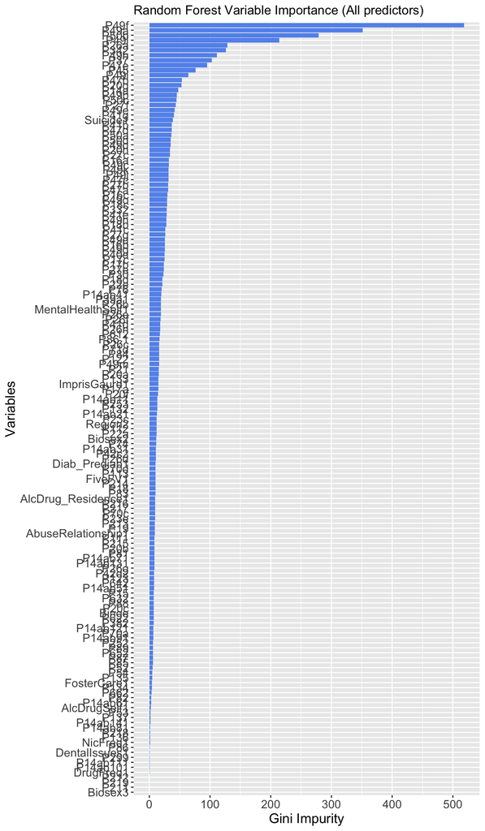

```r
## Create a plot of variable importance
var_impAll <- var_impAll %>%
  arrange(importance) %>%
  ggplot(aes(x=reorder(variables, importance), y=importance)) +
  geom_bar(stat='identity', fill = "cornflowerblue") +
  coord_flip() +
  xlab('Variables') +
  labs(title='Random Forest Variable Importance (All predictors)') + ylab("Gini Impurity") +
  theme(axis.text = element_text(size = 12),
        axis.title = element_text(size = 14))
#ggsave("/Users/sofiapozsonyiova/Documents/GitHub/707FinalProject/PGM/Model\ Building/var_impAll.png")

var_impAll
```

### Validation Set: All Variables Included

```r
## Generate predictions
y_hatsAll <- predict(
  object=forest_modelAll,
  newdata= final_test %>% select(-SelfPerceivedHealth,-P28))

# Get actual values
y_trueAll <- final_test$SelfPerceivedHealth

# Remove any rows with missing values
valid <- complete.cases(y_hatsAll, y_trueAll)
y_hatsAll <- y_hatsAll[valid]
y_trueAll <- y_trueAll[valid]

# Calculate accuracy
accuracy <- sum(y_hatsAll == y_trueAll) / length(y_trueAll)

# Print accuracy
print(accuracy)
```

```
## [1] 0.8439353
```

```r
# Confusion matrix
confusionMatrix(table(y_trueAll[!is.na(y_hatsAll)], y_hatsAll[!is.na(y_hatsAll)]))
```

```
## Confusion Matrix and Statistics
##
##
##        0    1
##   0 5399  968
##   1  190  863
##
##                Accuracy : 0.8439
##                  95% CI : (0.8355, 0.8521)
##     No Information Rate : 0.7532
##     P-Value [Acc > NIR] : < 2.2e-16
##
##                   Kappa : 0.5102
##
##  Mcnemar's Test P-Value : < 2.2e-16
##
##             Sensitivity : 0.9660
##             Specificity : 0.4713
##          Pos Pred Value : 0.8480
##          Neg Pred Value : 0.8196
##              Prevalence : 0.7532
##          Detection Rate : 0.7276
##    Detection Prevalence : 0.8581
##       Balanced Accuracy : 0.7187
##
##        'Positive' Class : 0
##
```

# Top 12 Variables: CV

## Data

```r
Train_sub12 <- Train_Model_Dev_Balanced %>% select(-P28) %>% dplyr::select(c(P49f,P49a,P50b,P49l,P26a,P34,P49h,P37,P47e,P45,P49i,P47b,SelfPerceivedHealth))
```

```r
# Initializing Random Forest
forest_model_12 <- train(
  SelfPerceivedHealth ~ .,
  data = Train_sub12,
  method = "rf",
  tuneGrid = data.frame(mtry = c(2,4,6,12)),
  trControl = trainControl(method = "cv",number = 10),
  metric = "Accuracy",
  na.action = na.omit)
```

```r
# Printing results
print(forest_model_12)
```

```
## Random Forest
##
## 8718 samples
##   12 predictor
##    2 classes: '0', '1'
##
## No pre-processing
## Resampling: Cross-Validated (10 fold)
## Summary of sample sizes: 7847, 7846, 7846, 7847, 7846, 7846, ...
## Resampling results across tuning parameters:
##
##   mtry  Accuracy   Kappa
##    2    0.8679755  0.7359522
##    4    0.8812803  0.7625619
##    6    0.8813940  0.7627896
##   12    0.8751997  0.7504010
##
## Accuracy was used to select the optimal model using the largest value.
## The final value used for the model was mtry = 6.
```

```r
forest_model_12$results
```

```
##   mtry  Accuracy     Kappa  AccuracySD     KappaSD
## 1    2 0.8679755 0.7359522 0.010206661 0.020414987
## 2    4 0.8812803 0.7625619 0.006600075 0.013201213
## 3    6 0.8813940 0.7627896 0.003744430 0.007488215
## 4   12 0.8751997 0.7504010 0.008035440 0.016073147
```

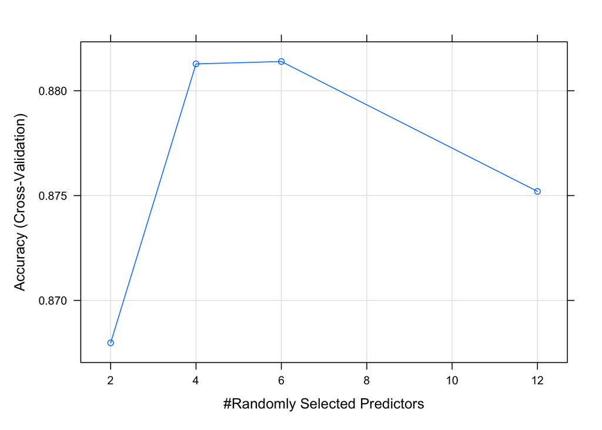

```r
#Visualizing results
plot(forest_model_12)
```

```r
# Final model Forest
forest_model_12$finalModel
```

```
##
## Call:
##  randomForest(x = x, y = y, mtry = min(param$mtry, ncol(x)))
##                Type of random forest: classification
##                      Number of trees: 500
## No. of variables tried at each split: 6
##
##         OOB estimate of  error rate: 11.52%
## Confusion matrix:
##      0    1 class.error
## 0 3730  629  0.14429915
## 1  375 3984  0.08602891
```

```r
## Get variable importance, and turn into a data frame
var_imp12 <- varImp(forest_model_12, scale=FALSE)$importance
var_imp12 <- data.frame(variables=row.names(var_imp12), importance=var_imp12$Overall)
var_imp12 %>% arrange(desc(importance))
```

```
##    variables importance
## 1       P49f   747.3440
## 2       P49a   481.9199
## 3       P50b   430.0420
## 4        P37   414.4996
## 5       P49l   365.8572
## 6        P45   362.5072
## 7       P47e   307.8919
## 8       P26a   276.9477
## 9       P47b   242.4704
## 10      P49i   238.5554
## 11      P49h   237.6448
## 12      P342   176.6296
```

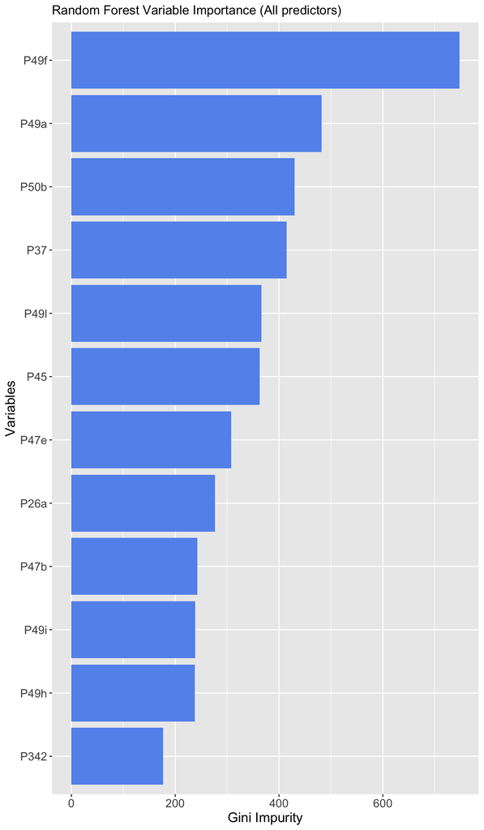

```r
## Create a plot of variable importance
var_imp12 <- var_imp12 %>%
  arrange(importance) %>%
  ggplot(aes(x=reorder(variables, importance), y=importance)) +
  geom_bar(stat='identity', fill = "cornflowerblue") +
  coord_flip() +
  xlab('Variables') +
  labs(title='Random Forest Variable Importance (All predictors)') + ylab("Gini Impurity") +
  theme(axis.text = element_text(size = 12),
        axis.title = element_text(size = 14))
#ggsave("/Users/sofiapozsonyiova/Documents/GitHub/707FinalProject/PGM/Model\ Building/var_impAll.png")

var_imp12
```

### Validation Set: Top 12

```r
## Generate predictions
y_hats12 <- predict(
  object=forest_model_12,
  newdata= final_test %>% select(-SelfPerceivedHealth,-P28))

# Get actual values
y_true12 <- final_test$SelfPerceivedHealth

# Remove any rows with missing values
valid <- complete.cases(y_hats12, y_true12)
y_hats12 <- y_hats12[valid]
y_true12 <- y_true12[valid]

# Calculate accuracy
accuracy <- sum(y_hats12 == y_true12) / length(y_true12)

# Print accuracy
print(accuracy)
```

```
## [1] 0.8195418
```

```r
# Confusion matrix
confusionMatrix(table(y_true12[!is.na(y_hats12)], y_hats12[!is.na(y_hats12)]))
```

```
## Confusion Matrix and Statistics
##
##
##        0    1
##   0 5250 1117
##   1  222  831
##
##                Accuracy : 0.8195
##                  95% CI : (0.8106, 0.8282)
##     No Information Rate : 0.7375
##     P-Value [Acc > NIR] : < 2.2e-16
##
##                   Kappa : 0.453
##
##  Mcnemar's Test P-Value : < 2.2e-16
##
##             Sensitivity : 0.9594
##             Specificity : 0.4266
##          Pos Pred Value : 0.8246
##          Neg Pred Value : 0.7892
##              Prevalence : 0.7375
##          Detection Rate : 0.7075
##    Detection Prevalence : 0.8581
##       Balanced Accuracy : 0.6930
##
##        'Positive' Class : 0
##
```

# Top 4 Variables: CV

## Data

```r
Train_sub4 <- Train_Model_Dev_Balanced %>% select(-P28) %>% dplyr::select(c(P49f,P49a,P50b,P49l,SelfPerceivedHealth))
```

```r
# Initializing Random Forest
forest_model_4 <- train(
  SelfPerceivedHealth ~ .,
  data = Train_sub4,
  method = "rf",
  tuneGrid = data.frame(mtry = c(1,2,4)),
  trControl = trainControl(method = "cv",number = 10),
  metric = "Accuracy",
  na.action = na.omit)
```

```r
# Printing results
print(forest_model_4)
```

```
## Random Forest
##
## 8718 samples
##    4 predictor
##    2 classes: '0', '1'
##
## No pre-processing
## Resampling: Cross-Validated (10 fold)
## Summary of sample sizes: 7846, 7846, 7847, 7846, 7847, 7846, ...
## Resampling results across tuning parameters:
##
##   mtry  Accuracy   Kappa
##   1     0.7907788  0.5815625
##   2     0.7892881  0.5785818
##   4     0.7859623  0.5719305
##
## Accuracy was used to select the optimal model using the largest value.
## The final value used for the model was mtry = 1.
```

```r
forest_model_4$results
```

```
##   mtry  Accuracy     Kappa  AccuracySD    KappaSD
## 1    1 0.7907788 0.5815625 0.009401452 0.01880586
## 2    2 0.7892881 0.5785818 0.012070759 0.02414506
## 3    4 0.7859623 0.5719305 0.013895885 0.02779641
```

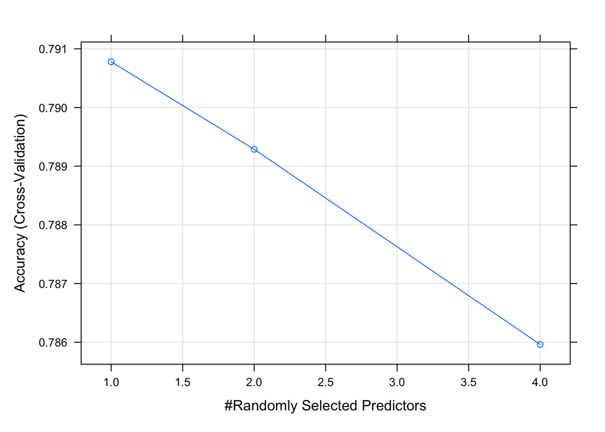

```r
#Visualizing results
plot(forest_model_4)
```

```r
# Final model Forest
forest_model_4$finalModel
```

```
##
## Call:
##  randomForest(x = x, y = y, mtry = min(param$mtry, ncol(x)))
##                Type of random forest: classification
##                      Number of trees: 500
## No. of variables tried at each split: 1
##
##         OOB estimate of  error rate: 21.01%
## Confusion matrix:
##      0    1 class.error
## 0 3452  907   0.2080752
## 1  925 3434   0.2122046
```

```r
## Get variable importance, and turn into a data frame
var_imp4 <- varImp(forest_model_4, scale=FALSE)$importance
var_imp4 <- data.frame(variables=row.names(var_imp4), importance=var_imp4$Overall)
var_imp4 %>% arrange(desc(importance))
```

```
##   variables importance
## 1      P50b   466.9740
## 2      P49f   416.0151
## 3      P49l   371.5920
## 4      P49a   369.5575
```

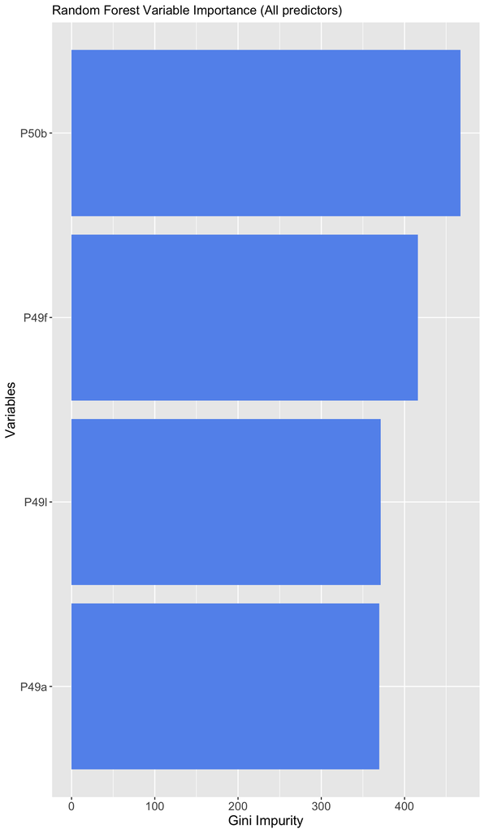

```r
## Create a plot of variable importance
var_imp4 <- var_imp4 %>%
  arrange(importance) %>%
  ggplot(aes(x=reorder(variables, importance), y=importance)) +
  geom_bar(stat='identity', fill = "cornflowerblue") +
  coord_flip() +
  xlab('Variables') +
  labs(title='Random Forest Variable Importance (All predictors)') + ylab("Gini Impurity") +
  theme(axis.text = element_text(size = 12),
        axis.title = element_text(size = 14))
#ggsave("/Users/sofiapozsonyiova/Documents/GitHub/707FinalProject/PGM/Model\ Building/var_impAll.png")

var_imp4
```

### Validation Set: Top 4

```r
## Generate predictions
y_hats4 <- predict(
  object=forest_model_4,
  newdata= final_test %>% select(-SelfPerceivedHealth,-P28))

# Get actual values
y_true4 <- final_test$SelfPerceivedHealth

# Remove any rows with missing values
valid <- complete.cases(y_hats4, y_true4)
y_hats4 <- y_hats4[valid]
y_true4 <- y_true4[valid]

# Calculate accuracy
accuracy <- sum(y_hats4 == y_true4) / length(y_true4)

# Print accuracy
print(accuracy)
```

```
## [1] 0.7908356
```

```r
# Confusion matrix
confusionMatrix(table(y_true4[!is.na(y_hats4)], y_hats4[!is.na(y_hats4)]))
```

```
## Confusion Matrix and Statistics
##
##
##        0    1
##   0 5018 1349
##   1  203  850
##
##                Accuracy : 0.7908
##                  95% CI : (0.7814, 0.8)
##     No Information Rate : 0.7036
##     P-Value [Acc > NIR] : < 2.2e-16
##
##                   Kappa : 0.4094
##
##  Mcnemar's Test P-Value : < 2.2e-16
##
##             Sensitivity : 0.9611
##             Specificity : 0.3865
##          Pos Pred Value : 0.7881
##          Neg Pred Value : 0.8072
##              Prevalence : 0.7036
##          Detection Rate : 0.6763
##    Detection Prevalence : 0.8581
##       Balanced Accuracy : 0.6738
##
##        'Positive' Class : 0
##
```

# All Variables: OOB

### Training: All Variables Included

```r
# Initializing Random Forest
forest_modelAll_OOB <- train(
  SelfPerceivedHealth ~ .,
  data = Train_All,
  method = "rf",
  tuneGrid = data.frame(mtry = c(2,12,63,126)),
  trControl = trainControl(method = "oob"),
  metric = "Accuracy",
  na.action = na.omit)
```

```r
# Printing results
print(forest_modelAll_OOB)
```

```
## Random Forest
##
## 8718 samples
##  126 predictor
##    2 classes: '0', '1'
##
## No pre-processing
## Resampling results across tuning parameters:
##
##   mtry  Accuracy   Kappa
##     2   0.8786419  0.7572838
##    12   0.9004359  0.8008718
##    63   0.9002065  0.8004129
##   126   0.8983712  0.7967424
##
## Accuracy was used to select the optimal model using the largest value.
## The final value used for the model was mtry = 12.
```

```r
forest_modelAll_OOB$results
```

```
##    Accuracy     Kappa mtry
## 1 0.8786419 0.7572838    2
## 2 0.9004359 0.8008718   12
## 3 0.9002065 0.8004129   63
## 4 0.8983712 0.7967424  126
```

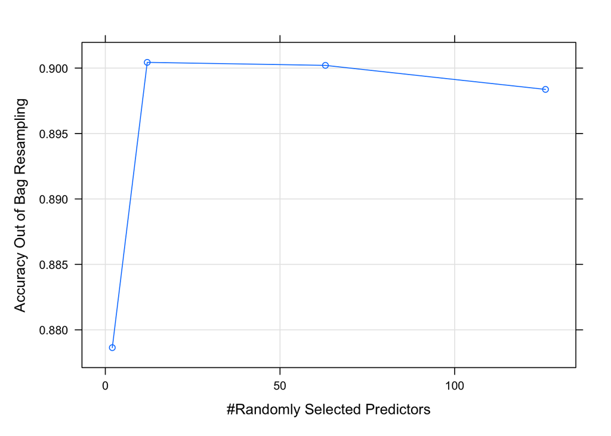

```r
#Visualizing results
plot(forest_modelAll_OOB)
```

```r
# Final model Forest
forest_modelAll_OOB$finalModel
```

```
##
## Call:
##  randomForest(x = x, y = y, mtry = min(param$mtry, ncol(x)))
##                Type of random forest: classification
##                      Number of trees: 500
## No. of variables tried at each split: 12
##
##         OOB estimate of  error rate: 9.85%
## Confusion matrix:
##      0    1 class.error
## 0 3829  530  0.12158752
## 1  329 4030  0.07547603
```

```r
## Get variable importance, and turn into a data frame
var_impAll <- varImp(forest_modelAll_OOB, scale=FALSE)$importance
var_impAll <- data.frame(variables=row.names(var_impAll), importance=var_impAll$Overall)
var_impAll %>% arrange(desc(importance))
```

```
##              variables   importance
## 1                 P49f 2.084176e+02
## 2                 P49a 1.904859e+02
## 3                 P50b 1.654027e+02
## 4                 P49h 1.348064e+02
## 5                 P342 1.271596e+02
## 6                 P49l 1.271578e+02
## 7                 P47e 1.256390e+02
## 8                 P49i 1.212190e+02
## 9                  P37 1.015710e+02
## 10                P26a 9.386142e+01
## 11                P47b 9.171641e+01
## 12                P49e 8.419795e+01
## 13                 P45 8.198944e+01
## 14                P49p 7.995927e+01
```

[output cut: 141 more lines]

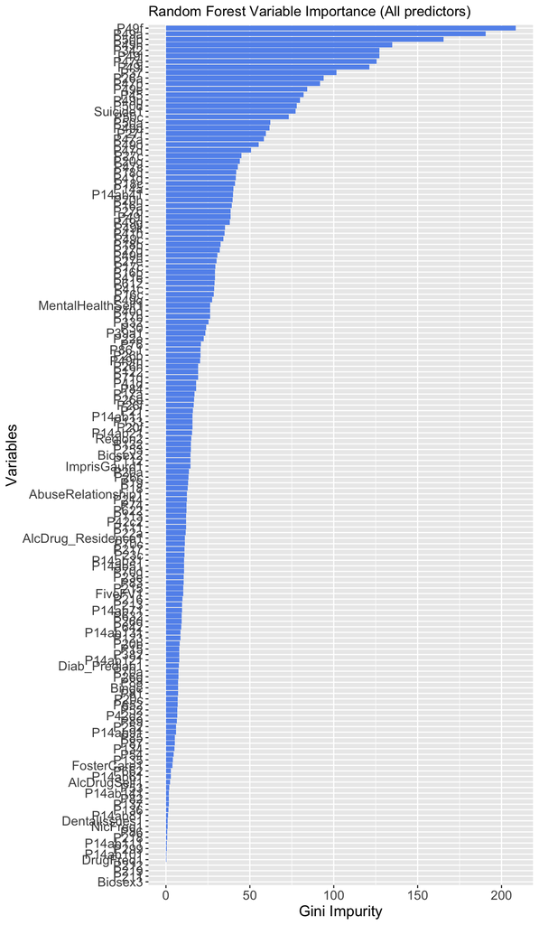

```r
## Create a plot of variable importance
var_impAll <- var_impAll %>%
  arrange(importance) %>%
  ggplot(aes(x=reorder(variables, importance), y=importance)) +
  geom_bar(stat='identity', fill = "cornflowerblue") +
  coord_flip() +
  xlab('Variables') +
  labs(title='Random Forest Variable Importance (All predictors)') + ylab("Gini Impurity") +
  theme(axis.text = element_text(size = 12),
        axis.title = element_text(size = 14))
#ggsave("/Users/sofiapozsonyiova/Documents/GitHub/707FinalProject/PGM/Model\ Building/var_impAll.png")

var_impAll
```

### Validation Set: All Variables Included

```r
## Generate predictions
y_hatsAll <- predict(
  object=forest_modelAll_OOB,
  newdata= final_test %>% select(-SelfPerceivedHealth,-P28))
```

```r
# Confusion matrix
confusionMatrix(table(final_test$SelfPerceivedHealth, y_hatsAll))
```

```
## Confusion Matrix and Statistics
##
##    y_hatsAll
##        0    1
##   0 5417  950
##   1  201  852
##
##                Accuracy : 0.8449
##                  95% CI : (0.8364, 0.853)
##     No Information Rate : 0.7571
##     P-Value [Acc > NIR] : < 2.2e-16
##
##                   Kappa : 0.5089
##
##  Mcnemar's Test P-Value : < 2.2e-16
##
##             Sensitivity : 0.9642
##             Specificity : 0.4728
##          Pos Pred Value : 0.8508
##          Neg Pred Value : 0.8091
##              Prevalence : 0.7571
##          Detection Rate : 0.7301
##    Detection Prevalence : 0.8581
##       Balanced Accuracy : 0.7185
##
##        'Positive' Class : 0
##
```